# Claim_01_Markdown

Group 86 - Jana Schneider, Jana Jeggle, Felix Heim, Leon Gaertner

4 12 2020

```r
# Load the libraries we need
library(magrittr)
library(data.table)
library(ggplot2)
library(tidyr)
library(dplyr)
library(maps)
library(ggrepel)
library(rgeos)
library(sf)
library(rnaturalearth)
library(rnaturalearthdata)
library(ggpubr)
library(patchwork)
library(hrbrthemes)
```

```r
# import files: Time, RKI data
time <- fread("./extData/Time.csv")
policy <- fread("./extData/Policy.csv")
policy1 <- fread("./extData/Policy.csv")
RKI_data <- fread("./extData/DE_InfectionCases.csv")
patientinfo <- fread("./extData/PatientInfo.csv")
case <- fread("./extData/Case.csv")
searchtrend <- fread("./extData/SearchTrend.csv")
region <- fread("./extData/Region.csv")
```

## Claim 1 - Search Data Cases

**Our initial motivation:**

- We assume that the coronavirus had been spreading several months before cases were officially reported. To support our claim, we use available search data.

**Claim description in more detail:**

- The number of searches for covid-related symptoms shows an increase in the beginning of the pandemic (Beginning of 2020)
- The number of daily confirmed cases correlates with the searches for covid-related symptoms

**Our approach:**

We join the tables patientInfo and Searchtrend by confirmed_date. Then, we plot the number of daily cases and searches as line chart. As the search data is not comparable to the daily confirmed cases, we introduce an additional y-Axis for the search data.

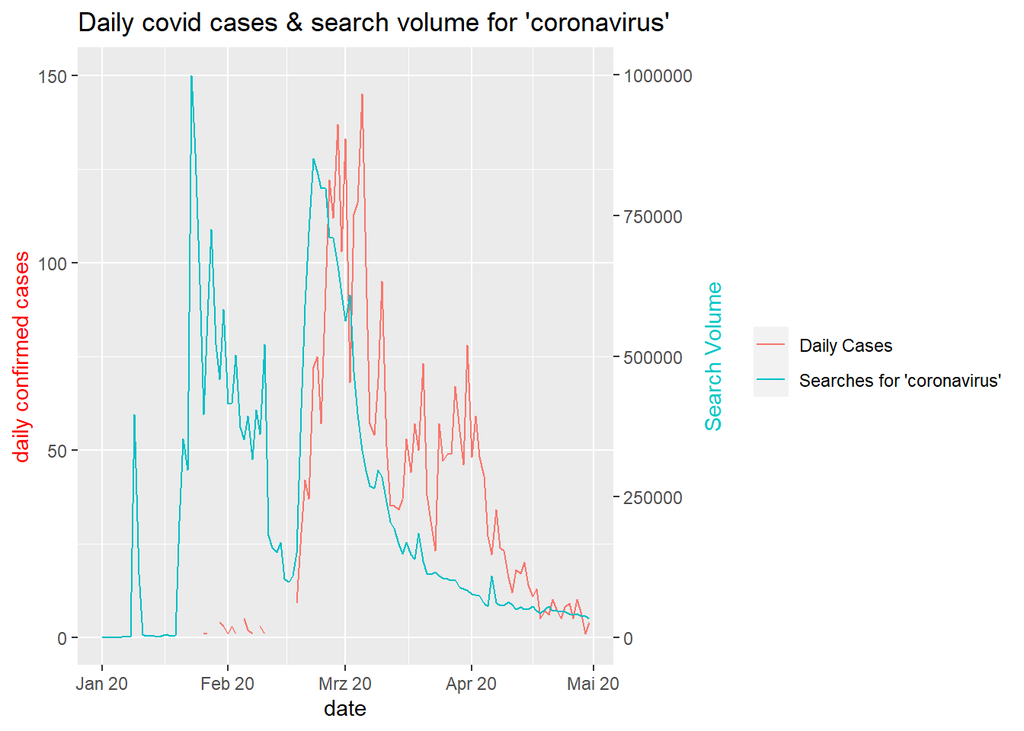

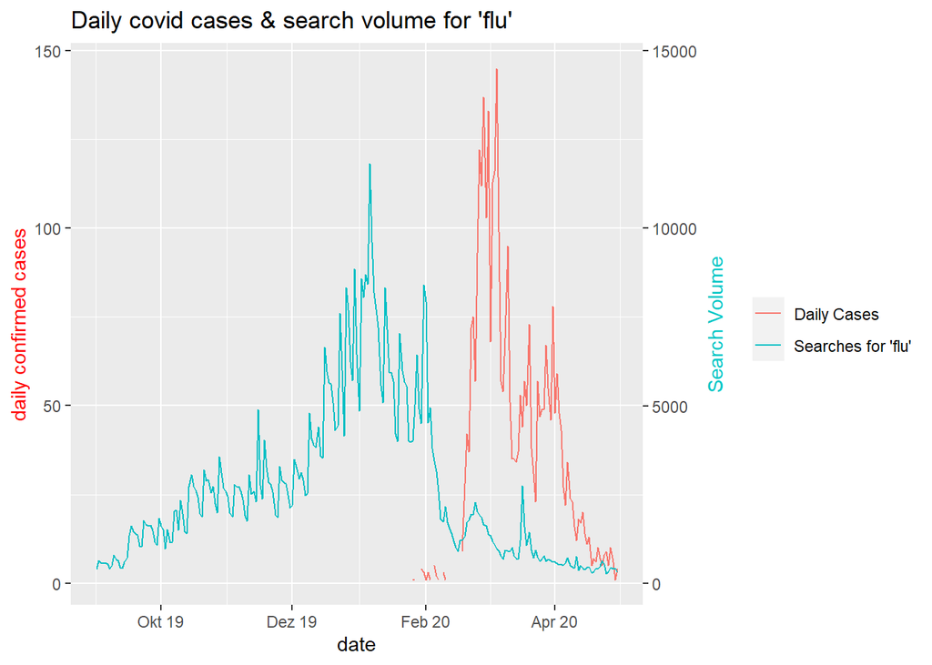

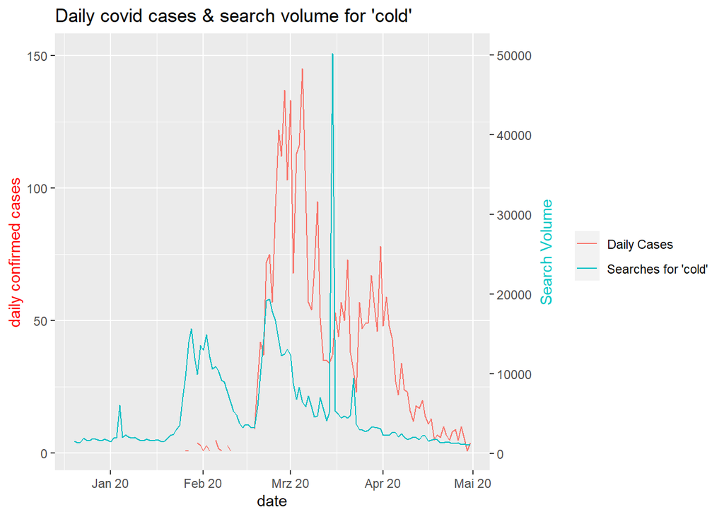

**Short Analysis** The term “coronavirus” was searched many times more often in comparison to the other two available search terms “flu” and “cold”. Both the search term “coronavirus” and “cold” show partial similarity in its course with the daily confirmed cases (e.g. strong increase in mid-February).

The gradual increase of the search term “flu” starting in October 2019 could be an indicator of the first (not-tested) covid cases. But there is further investigation needed to differentiate the data from the annual flu-season.

## Claim 02

#### Strict lockdown measures have prevented a thorough spread in South Korea

**Our initial motivation:**

- After a massive increase in daily cases, it appears that the government of South Korea was able to reduce the number of daily cases remarkably within a few days and continued to retain a constant low level.

**Claim description in more detail:**

- Stricter lockdown measures lead to a lower outbreak of the Covid-19 Virus
- Compared to other countries, for example Germany, the government of South Korea reacted more effectively and efficiently

**Our approach:**

- We first compared the daily cases of South Korea with the ones of Germany.
- Next we looked at the different types of government policy’ measures.
- Within each type of policy we analysed the different measures in terms of time to daily cases.

[figure not shown]

**Short Analysis**

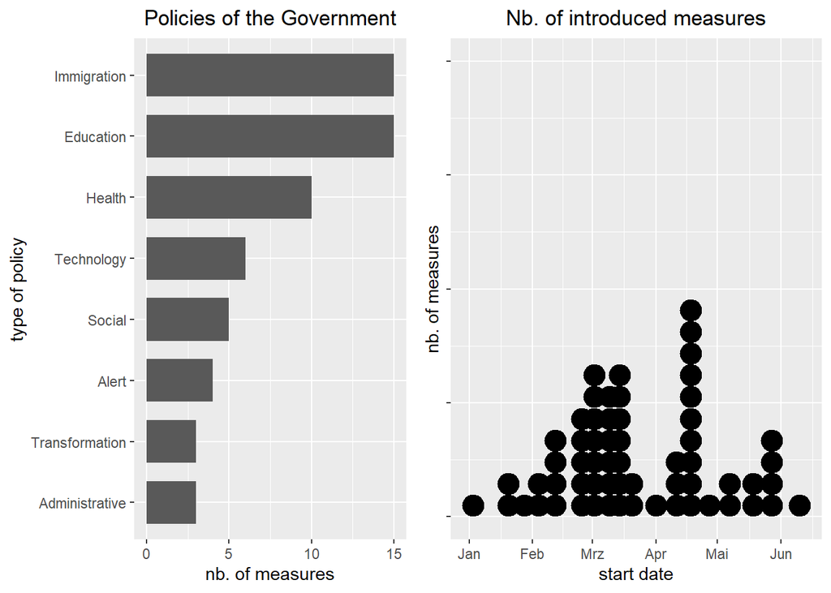

**Short analysis**

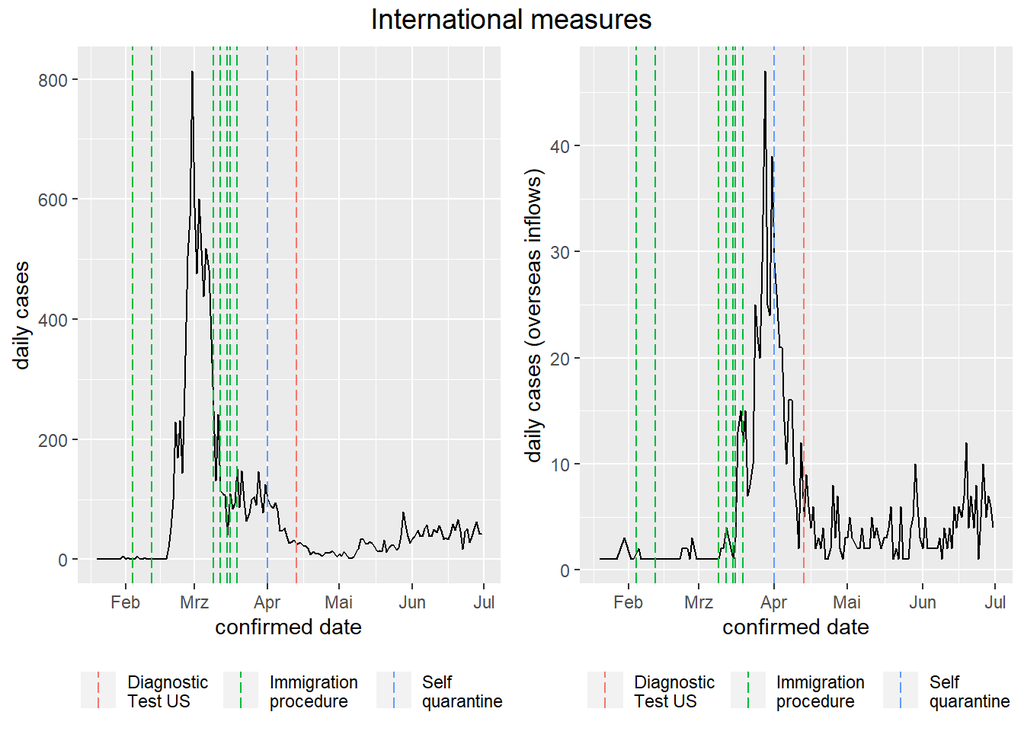

**Short Analysis**

- After the number of daily cases related to overseas inflow reached a very high level, the government of South Korea imposed a mandatory 14-day Self-Quarantine. It seems that after a short time the number of daily cases related to overseas inflow could be reduced sharply and retained a relatively stable level.
- After experiencing a peak in numbers, the government of South Korea establisehd special immigration procedures for foreign countries in order to prevent another severe increase in numbers caused by people entering the country. However, one can note that shortly afterwards the number of daily cases related to overseas inflow first increased before plunging afterwards.

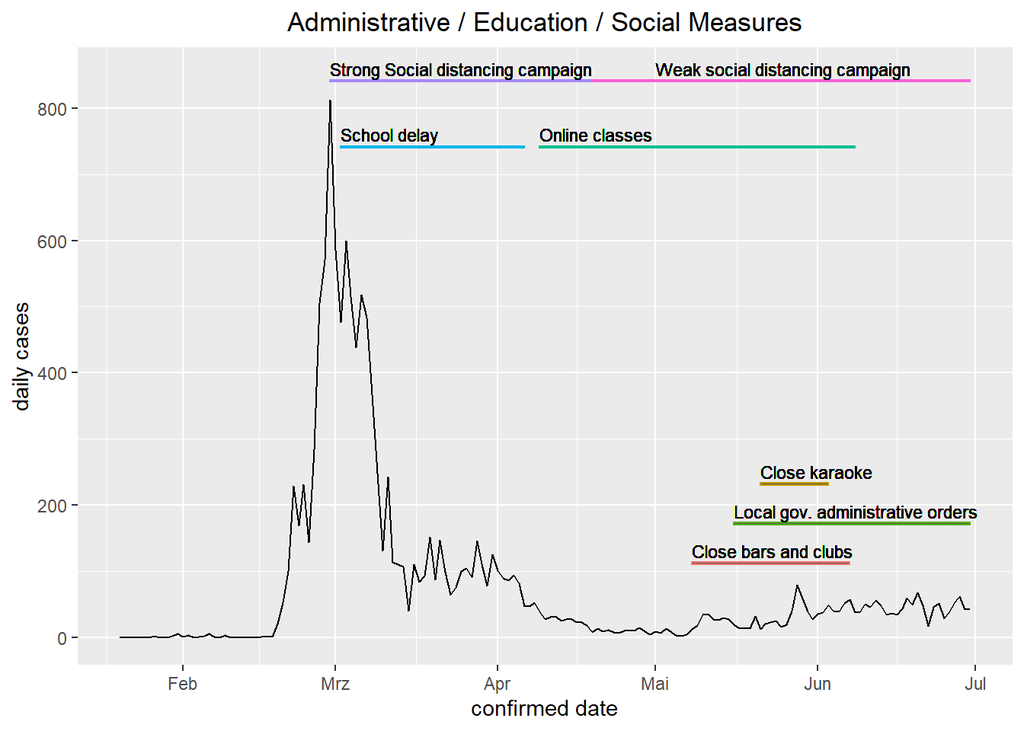

**Short Analysis**

- After the number of daily cases have reached peak in March, numerous meausures with the aim of social distancing, such as delaying school start, were introduced. It seems that through these measures the number of daily cases could be reduced.
- In the begining of May, after the number of daily cases tended to increase again, further public indoor gathering places were forced closed. It seems that through that another severe outbreak was prevented.

## Claim 03

#### Superspreader Events were the reason the Covid cases in South Korea turned out to be so intense in the first place.

**Our initial motivation:**

- When Covid first reach South Korea the number of cases was relatively low. However, with the “mysterious” patient Number 31, the serious increase in daily cases in South Korea began. A lot ot people worldwide including the local government blamed a Christian ‘Cult’ for this, since one member seemed to have spread the virus.

**Claim description in more detail:**

- Without this particular spreader event in the Shincheonji Church in Daegu the Covid-spread would have been seriously lower.
- In fact, one could argue that without those spreader events the Covid-spread in South Korea wouldn’t have been “serious” at all.

**Our approach:**

- In order to see, whether the public media was right, and the Church did indeed cause the first “serious” spread of the virus we first had a look at the most common reasons for a Covid infection within South Korea.
- We then created a graph showing the daily cases related to the main spreader events in comparison to the overall daily cases.
- Finally, we created a first map of South Korea showing the outbreaks in the different regions together with the specific locations of the different spreader events.

#### First part of the analyis

**Who was infected by with infection case? What role do the super spreader events play?**

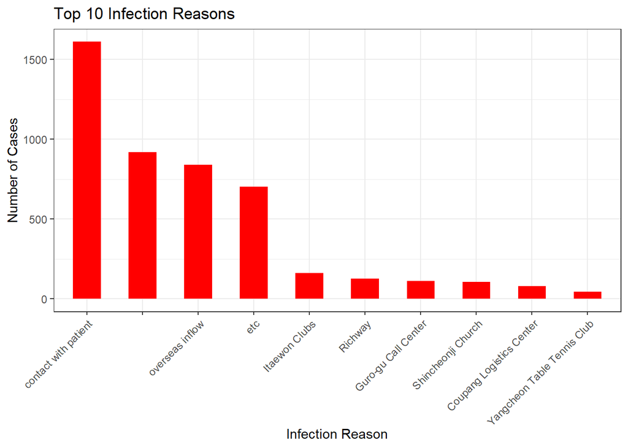

##### Short analysis:

- Seems like apart from contact with a patient and oversees inflow, the main reasons for getting Covid-19 were related to some main events that happened throughout the country
- The most cases are related to the Itaewon clubs. The church that we read about in the news is on 4th place when we don’t count contact with patient, overseas inflow etc.

Following, we’ll create a graph comparing the total daily cases with the daily cases related to the super spreader events. Since the “patientinfo” table represents only a sample of the total amount of cases, we will first show, that patientinfo can indeedn be seen as a representative sample of the total amount of cases.

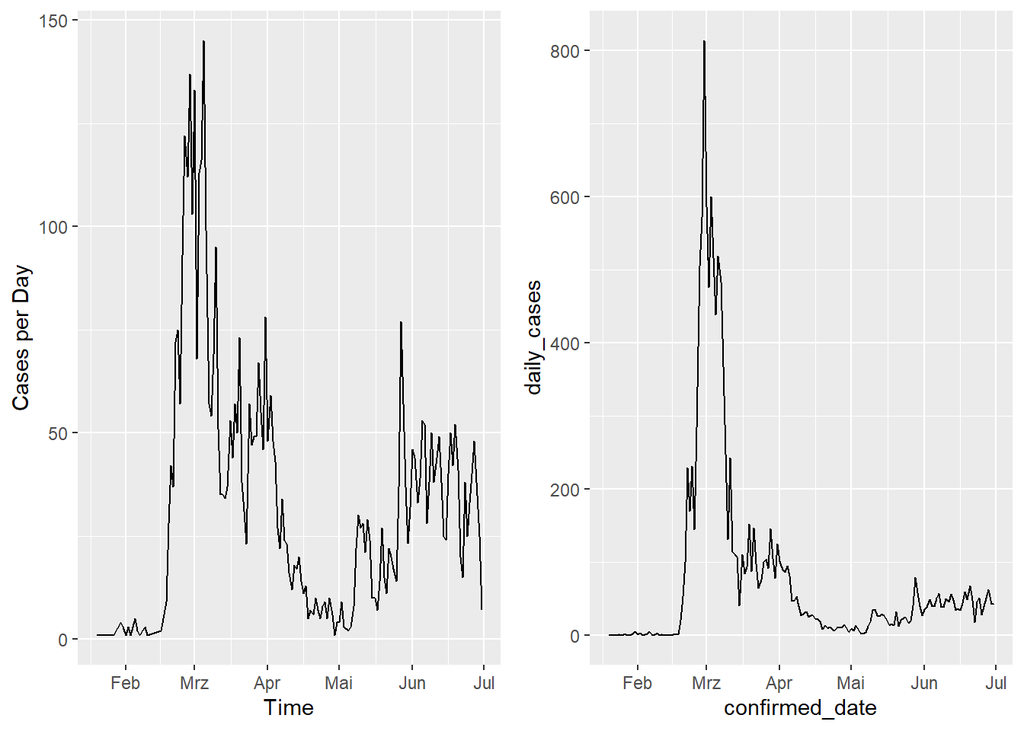

As one can see both graph lines follow a similar pattern over the same time period. Therefore, we will assume that we can treat patientinfo as a representative sample.

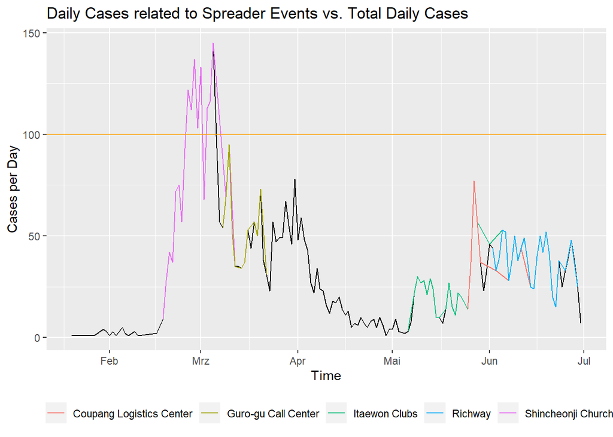

**Short analyis:**

- The different spreader events match the daily cases over time pretty well!
- Especially the first event (the Church!) shows that when cases exploded, a whole lot was related to the church everyone is blaming
- Let’s see when exactly the main event happened and match only the first event with overall cases

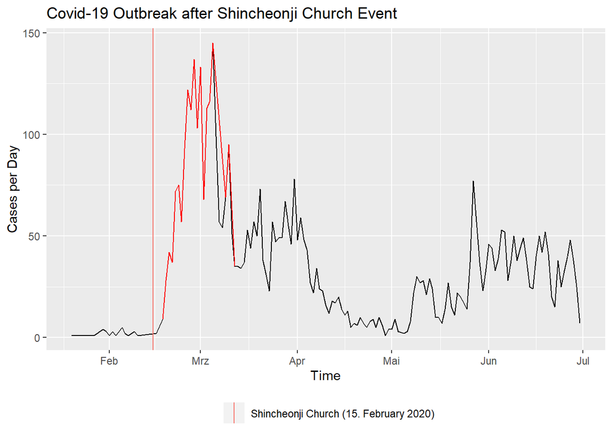

**Short analyis**

- This matches pretty well
- Of course we need to take into account that the “real” amount of daily cases goes up to 800 so the almost 150 daily cases at this one day in March connected to the Church are not the total number of cases that day
- Still, the impact the church outbreak had on the whole Covid situation in South Korea is pretty intense

#### Second part of the analyis

**Where exactly did the events take place? Are we able to see a connection between large outbreaks and the Spreader events?**

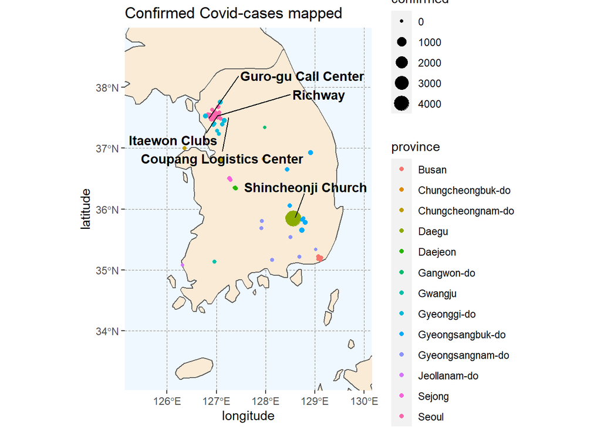

**Short analysis:**

- One can clearly see the connection between large outbreak locations and the spreader events. While multiple cases and events occurred in Seoul (North-West part of South Korea), the most interesting thing is the very first spreader event in Daegu (Shincheonji Church)
- Interesting is as well, that his map shows not only part of the acutal cases (such as the Patientinfo table) but a real overview of the number of cases occurred in the different areas.
- Thus, one can clearly see the influence the main first spreader event in the Shincheonji Church in Daegu had. One could argue that without the event the cases might have been seriously lower. However, further analysis would have had to be conducted in order to confirm this.